# 第六單元：基礎統計 with R

中山大學管理學院 第五組

2019-03-30 14:43:29

### 🗿 問題討論：

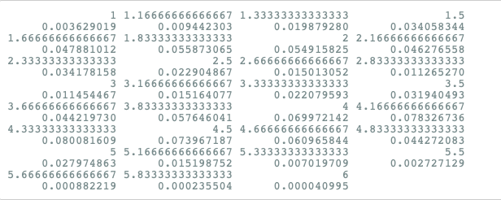

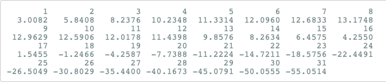

# 8次x5$ = 40元，期望值為13.1748 （如上圖，計算程式附在下面）  
將獲利的期望值和賭金的比值稱為「期望投資報酬率」 …  
■ 「最大期望投資報酬率」和「最大期望報酬」的投資策略是一樣的嗎？  
#不一樣  
■ 你認為哪一個策略目標比較好呢？ 為什麼？  
#以本題題幹為前提，最大期望報酬策略比較好，因為實拿獲利較高；若題目假設改變，例如:獎金、賭金條件改變，則無法確定何種策略為佳

```r
Waits <- faithful$waiting / 10

summary(Waits)
```

```
   Min. 1st Qu.  Median    Mean 3rd Qu.    Max.
   4.30    5.80    7.60    7.09    8.20    9.60
```

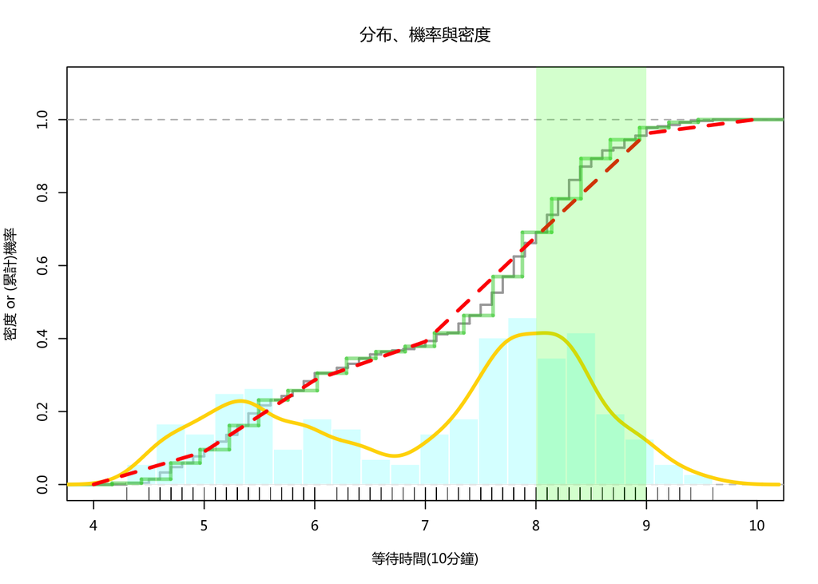

```r
# Frame
par(cex = 0.7)
par(family='MicrosoftYaHei')
plot(0,0,xlim=c(4,10),ylim=c(0,1.1),xlab="等待時間(10分鐘)",
     ylab="密度 or (累計)機率", main="分布、機率與密度")
abline(h=1, col='lightgray', lwd=0.25, lty=2)


# Empirical PDF
rug(Waits)
# Empirical CDF
plot(ecdf(Waits), cex=0, verticals=T, lwd=2, col='darkgray', add=T)
## add = T 會將該圖層加在原先的圖上 , 不會額外再重新繪圖


# Histogram PDF
Bins = 20                             # no. bins
bx = seq(min(Waits), max(Waits), length= (Bins+1) ) # break sequence
hist(Waits, col="#B3FFFF7F", border="white", ylim=c(0,1.1),
     freq=F, breaks=bx, add=T)
abline(h=0, col='lightgray', lwd=0.25)
# Histogram CDF
adj = (bx[2] - bx[1])/2
steps = stepfun(bx-adj, c(0, sapply(bx, function(b) mean(Waits <= b))))
plot(steps, cex=0, col='#33CC337F', lwd=3, lty=1, add=T)

# Smooth PDF
Adjust = 0.5    # bandwidth adjustment
DEN = density(Waits, adjust = Adjust)
lines(DEN, col='gold', lwd=3)
# Smooth CDF
PDF = approxfun(DEN$x, DEN$y, yleft=0, yright=0)
x = seq(4,10,1)
y = sapply(x, function(i) integrate(PDF, -Inf, i)$value)
lines(x, y, col='red', lwd=3, lty=2)

# Mark Range
x1 = 8; x2 = 9
rect(x1,-0.1,x2,1.2,col= rgb(0,1,0,alpha=0.2),border=NA)
```

```r
# x = seq(x1, x2, length=100)
# polygon(c(x, x2, x1),  c(PDF(x), 0, 0), col="#FF99003F", border=NA)
# Calculate Probability
(integrate(PDF, x1, x2)$value)
```

```
[1] 0.28275
```

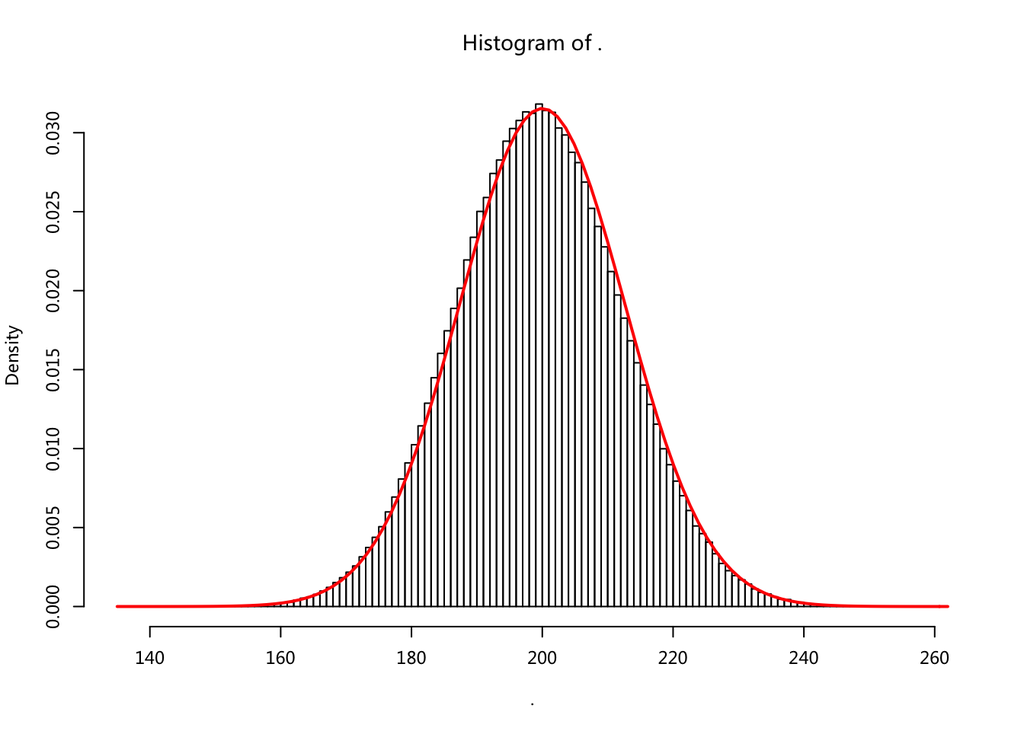

```r
###############################
rbinom(1000000, 1000, 0.2) %>% hist(breaks=100,freq=F)
curve(dnorm(x,mean=200,sd=sqrt(160)), col='red', lwd=2, add=T)
```

```r
faithful %>% head(10)
```

```
   eruptions waiting
1      3.600      79
2      1.800      54
3      3.333      74
4      2.283      62
5      4.533      85
6      2.883      55
7      4.700      88
8      3.600      85
9      1.950      51
10     4.350      85
```

```r
D = faithful$eruptions  # copy to a short name
summary(faithful)
```

```
   eruptions       waiting
 Min.   :1.60   Min.   :43.0
 1st Qu.:2.16   1st Qu.:58.0
 Median :4.00   Median :76.0
 Mean   :3.49   Mean   :70.9
 3rd Qu.:4.45   3rd Qu.:82.0
 Max.   :5.10   Max.   :96.0
```

```r
adj = (bx[2] - bx[1])/2
steps = stepfun(bx-adj, c(0, sapply(bx, function(b) mean(D <= b))))


# Smooth PDF
Adjust = 1    # bandwidth adjustment
DEN = density(D, adjust = Adjust) #如果沒有調整adjust，原本設定就是1

# Smooth CDF
PDF = approxfun(DEN$x, DEN$y, yleft=0, yright=0)
x = seq(1,6,0.1)
y = sapply(x, function(i) integrate(PDF, -Inf, i)$value)


# Mark Range
x1 = 3.8; x2 = 4.8

# x = seq(x1, x2, length=100)
# polygon(c(x, x2, x1),  c(PDF(x), 0, 0), col="#FF99003F", border=NA)
# Calculate Probability
(integrate(PDF, x1, x2)$value)
```

```
[1] 0.41995
```

```r
###############################
# 第4題計算期望值程式
EveryProb <- rep(0,31)
names(EveryProb) <- seq(1,6,(1/6))
j <- 1
for ( i in seq(1,6,(1/6)) ) {
  EveryProb[j] <- integrate(PDF, i, (i+(1/6)))$value
  j <- j + 1
}
EveryProb
```

```
               1 1.16666666666667 1.33333333333333              1.5
     0.003629019      0.009442303      0.019879280      0.034058344
1.66666666666667 1.83333333333333                2 2.16666666666667
     0.047881012      0.055873065      0.054915825      0.046276558
2.33333333333333              2.5 2.66666666666667 2.83333333333333
     0.034178158      0.022904867      0.015013052      0.011265270
               3 3.16666666666667 3.33333333333333              3.5
     0.011454467      0.015164077      0.022079593      0.031940493
3.66666666666667 3.83333333333333                4 4.16666666666667
     0.044219730      0.057646041      0.069972142      0.078326736
4.33333333333333              4.5 4.66666666666667 4.83333333333333
     0.080081609      0.073967187      0.060965844      0.044272083
               5 5.16666666666667 5.33333333333333              5.5
     0.027974863      0.015198752      0.007019709      0.002727129
5.66666666666667 5.83333333333333                6
     0.000882219      0.000235504      0.000040995
```

```r
EveryProb <- sort(EveryProb, decreasing = T)

E <- rep(0,31)
names(E) <- c(1:31)
for ( i in 1:31 ) {

  E[i] <- ( 100 * (sum(EveryProb[1:i])) ) - ( 5*i )

}
E
```

```
       1        2        3        4        5        6        7        8
  3.0082   5.8408   8.2376  10.2348  11.3314  12.0960  12.6833  13.1748
       9       10       11       12       13       14       15       16
 12.9629  12.5906  12.0178  11.4398   9.8576   8.2634   6.4575   4.2550
      17       18       19       20       21       22       23       24
  1.5455  -1.2466  -4.2587  -7.7388 -11.2224 -14.7211 -18.5756 -22.4491
      25       26       27       28       29       30       31
-26.5049 -30.8029 -35.4400 -40.1673 -45.0791 -50.0555 -55.0514
```

```r
max(E)
```

```
[1] 13.175
```

```r
EveryProb[1:8] %>% sum
```

```
[1] 0.53175
```